# Prototype - Fuel Mapping for CFFDRSv2.0

SRM-LQ

24/02/2022

## Action

Natural Resources Canada is seeking the development of a software solution for the creation of high-resolution vegetation mapping data of up to 1m resolution in wildland urban interface areas and wildland areas near communities to enable detailed fire behaviour prediction, fire hazard assessement and fire hazard mitigation activity planning.

- NRC Grant Information available here https://www.ic.gc.ca/eic/site/101.nsf/eng/00157.html

Lots of great tools have already been developed in the new [cffddrs R-package](https://cran.r-project.org/web/packages/cffdrs/cffdrs.pdf) built specifically for developing the two main components of the Canadian Forest Fire Danger Rating System: Fire Weather Index and Fire Prediction Behaviour, which include variables for forest fuels classes and their climatically situated moisture content in coded index: Fine Fuel Moisture Code (FFMC), Duff Moisture Code (DMC), Drought Code (DC). The first two FFMC and DMC are essential to the Wotton and Beverly’s stand-adjusted CFFDRS model. We need to check up on this, but this model may be what the NRC are looking for in applications for this grant competition, considering what we’re finding in their personal and official online repos.

Some good info therein mentions that the ‘FWI System outputs are determined from daily noon weather observations: temperature, relative humidity, wind speed, and 24-hour rainfall’. There is also a FWI test dataset ‘test_fwi’ showing what the proposed software should be able to source, process, and package as per contract deliverables:

```r
library(cffdrs)
print(as_tibble(test_fwi), n = 10)
```

```
## # A tibble: 48 × 9
##     long   lat    yr   mon   day  temp    rh    ws  prec
##    <int> <int> <int> <int> <int> <dbl> <int> <int> <dbl>
##  1  -100    40  1985     4    13  17      42    25   0
##  2  -100    40  1985     4    14  20      21    25   2.4
##  3  -100    40  1985     4    15   8.5    40    17   0
##  4  -100    40  1985     4    16   6.5    25     6   0
##  5  -100    40  1985     4    17  13      34    24   0
##  6  -100    40  1985     4    18   6      40    22   0.4
##  7  -100    40  1985     4    19   5.5    52     6   0
##  8  -100    40  1985     4    20   8.5    46    16   0
##  9  -100    40  1985     4    21   9.5    54    20   0
## 10  -100    40  1985     4    22   7      93    14   9
## # … with 38 more rows
```

A quick and data-light prototype pipeline to produce these two variables was tested and documented below. This pipeline attempts to produce these two moisture codes in raster format using the fwiRaster function. All resources and package lists were also stored in a github repository, along with its virtual environment settings ready for cloning here: https://github.com/seamusrobertmurphy/Wildfire-Fuel-Mapping-CFFDRS-2.0

# 1 Import

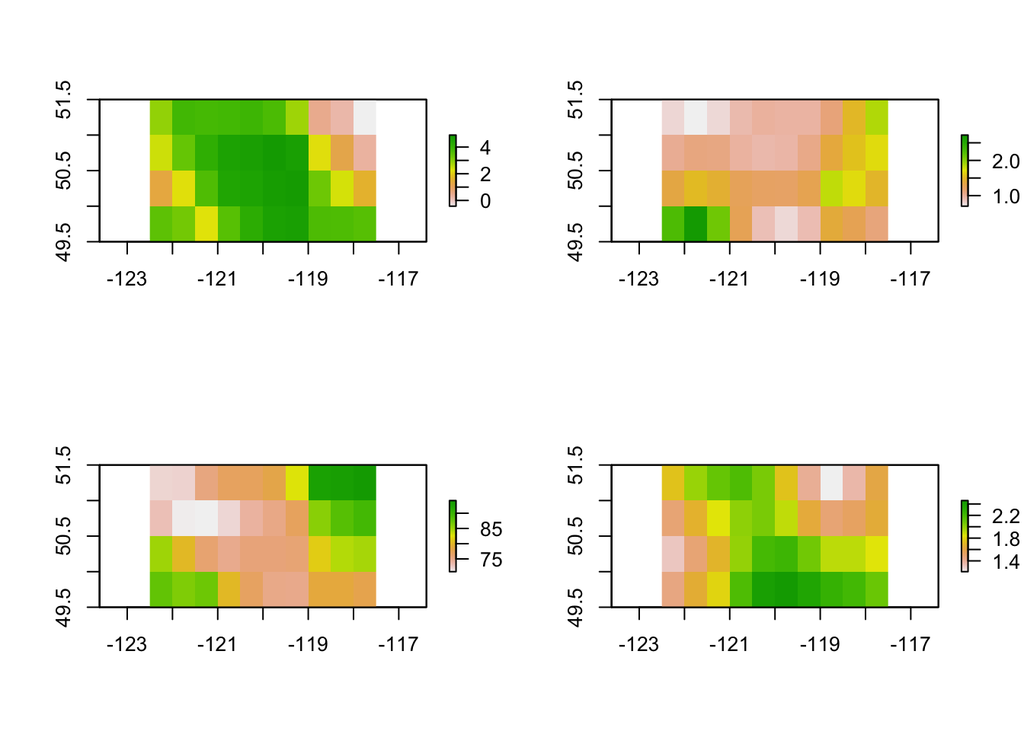

```r
temp = raster("./Data/temp.nc")
prec = raster("./Data/prec.nc")
rh = raster("./Data/rh.nc")
ws = raster("./Data/ws.nc")

names(temp) = 'temp'
names(prec) = 'prec'
names(rh) = 'rh'
names(ws) = 'ws'

par(mfrow = c(2, 2))
plot(temp)
plot(prec)
plot(rh)
plot(ws)
```

# 2 Tidy

Interpolate climate predictors were assembled as raster stack to fit the fwiRaster function.

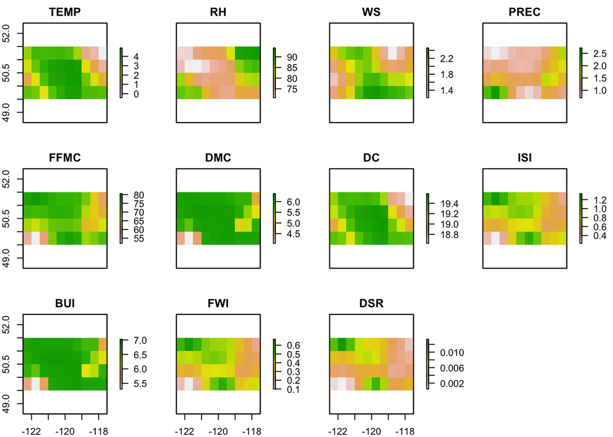

```r
stack = stack(temp, rh, ws, prec)
fwi_outputs = fwiRaster(stack)
plot(fwi_outputs)
```

# 3 Dataframe option

The following includes data processing functions for potential inputs as dataframe objects also possible in the cffdrs package

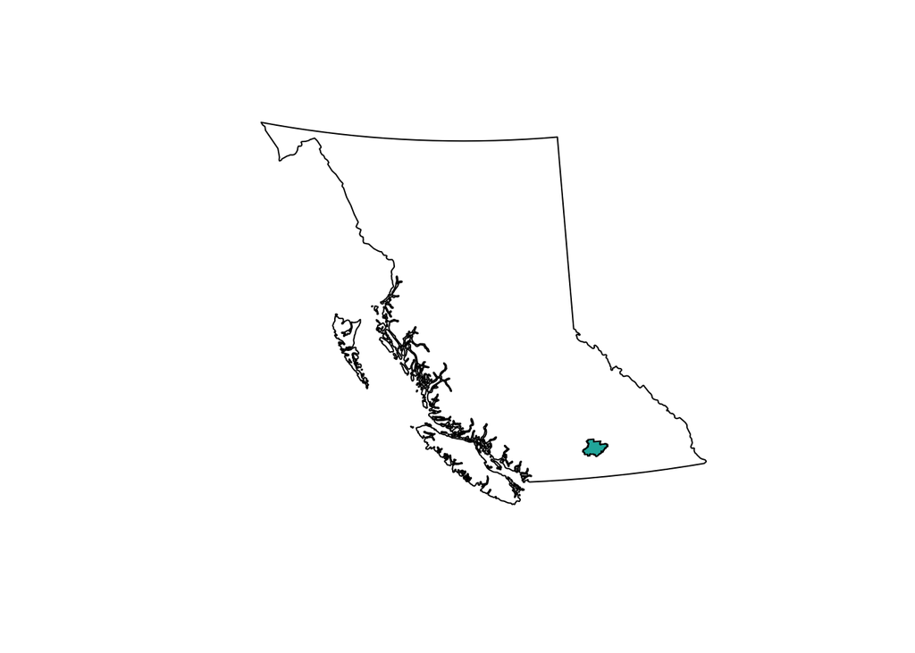

```r
climate_vars = read.csv("./Data/power_nasa_kelowna.csv")
climate_vars_sf = st_as_sf(climate_vars, coords = c("LAT", "LON"))
raster_template = raster(xmn=49.25, xmx=51.25, ymn=-122.25, ymx=-116.25, res=20, crs = "EPSG:3005")

temp = climate_vars_sf["T2M"]
temp = dplyr::rename(temp, temp = T2M)
temp = rasterize(temp, raster_template, res=20)

rh = climate_vars_sf["RH2M"]
rh = dplyr::rename(rh, rh = RH2M)
rh = rasterize(rh, raster_template, res=20)

ws = climate_vars_sf["WS10M"]
ws = dplyr::rename(ws, ws = WS10M)
ws = rasterize(ws, raster_template, res=20)

prec = climate_vars_sf["PRECTOTCORR"]
prec = dplyr::rename(prec, prec = PRECTOTCORR)
prec = rasterize(prec, raster_template, res=20)

stack = stack(temp, rh, ws, prec)
fwiRasters = fwiRaster(stack)

bc <- bc_bound()
plot(st_geometry(bc))
region = regional_districts()
kelowna <- region[region$ADMIN_AREA_NAME == "Regional District of Central Okanagan", ]
plot(st_geometry(kelowna), col = "lightseagreen", add = TRUE)
```

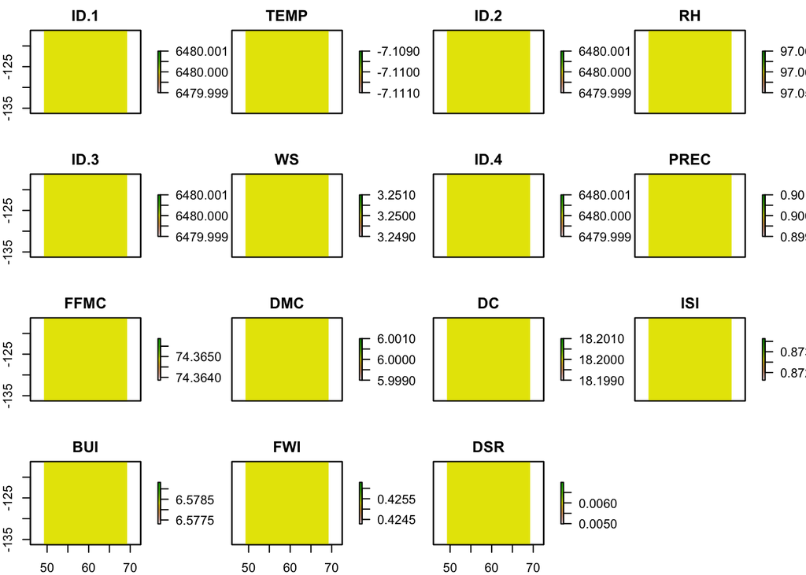

```r
plot(fwiRasters, add=TRUE)
```